# Cybersecurity 🪪 Intrusion 🦠 Detection Dataset

## link: https://www.kaggle.com/datasets/dnkumars/cybersecurity-intrusion-detection-dataset

### each observation represents a single network session, it’s one row of data showing what happened during that specific session

### such as like packet size, login attempts, encryption used, browser, and more, and whether a attack was detected

### i picked this dataset because cybersecurity is the part of cs i’m most interested in, most of my classes next semester revolve around it

### so i thought it would be nice learn a bit more about trends in the field

### variables:

#### session_id: unique session identifier. qualitative, nominal

#### network_packet_size: size of packets. quantitative, continuous

#### protocol_type: type of network protocol. qualitative, nominal

#### login_attempts: number of login tries. quantitative, discrete

#### session_duration: how long the session lasted (in seconds). quantitative, continuous

#### encryption_used: type of encryption used. qualitative, nominal

#### ip_reputation_score: suspiciousness score (0 to 1). quantitative, continuous

#### attack_detected: 1 if attack happened, 0 if not. qualitative, binary (nominal)

#### failed_logins: number of failed login attempts. quantitative, discrete

#### browser_type: browser used (chrome, firefox, etc.). qualitative, nominal

#### unusual_time_access: 1 if session happened at weird time, 0 if not. qualitative, binary (nominal)

### changes:

#### accounts, which will be addressed separately

```python
import pandas as pd
import seaborn as sns
import matplotlib.pyplot as plt
from sklearn.model_selection import train_test_split
from sklearn.linear_model import Lasso
from sklearn.linear_model import Ridge
from sklearn.metrics import r2_score, mean_squared_error, confusion_matrix
from sklearn.metrics import accuracy_score, precision_score
from sklearn.linear_model import LogisticRegression
from sklearn.preprocessing import StandardScaler
import matplotlib.ticker as mtick
import warnings
warnings.filterwarnings("ignore")
```

```python
df = pd.read_csv('cyberData.csv')
filtered_data = df[
    (df['login_attempts'] <= 10) & (df['session_duration'] <= 3600) & (df['failed_logins'] <= 3)
].copy()

filtered_data.to_csv('filtered_cyberData.csv', index=False)

print(f"before: {df.shape}")
print(f"afer: {filtered_data.shape}")
print(f"removed:{len(df) - len(filtered_data)}")
```

```
before: (9537, 11)
afer: (9090, 11)
removed:447
```

### Which browser types are most frequently targeted in cyber attacks?

#### Hypothesis: Chrome due to its popularity, will have most cyber attacks.

```python
cyberData = pd.read_csv("Downloads/cyberData.csv")
cyberData.to_csv("cyberData.csv", index=False)
df = df.dropna()
```

[figure not shown]

```python
browser_attack_rate = cyberData.groupby("browser_type")["attack_detected"].mean().reset_index()

browser_attack_rate_sorted = browser_attack_rate.sort_values("attack_detected", ascending=False)

plt.figure(figsize=(15, 5))
sns.barplot(
    y="browser_type",
    x="attack_detected",
    data=browser_attack_rate_sorted,
    palette="Blues_d"
)

plt.title("Browser Types Attack Rate Analysis", fontsize=15)
plt.xlabel("Attack Rate (%)", fontsize=12)
plt.ylabel("Browser Type", fontsize=12)
plt.gca().xaxis.set_major_formatter(mtick.PercentFormatter(.7))
plt.tight_layout()
plt.show()
```

### interpretation:

#### i first thought Chrome would have the highest attack rate because of its popularity, but the data shows that

#### the "Unknown" browser type had the highest attack rate, and according to the original poster, the "Unknown" browser type

#### most likely refers to automated scripts or bots, which often don't send correct browser data, making them harder to detect

#### and commonly used in cyberattacks using brute force attempts

### How do session durations relate to the likelihood of a cyberattack?

#### Hypothesis: Longer session durations are more likely associated with cyberattacks.

```
accuracy: 0.7091194968553459
percision: 0.7224606580829757
```

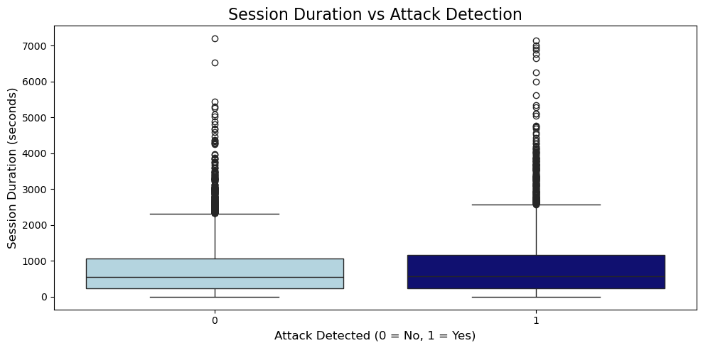

```python
X = cyberData[['session_duration', 'failed_logins', 'ip_reputation_score', 'protocol_type']]  #independent variables
y = cyberData['attack_detected']  #dependent variable

X = pd.get_dummies(X, columns=['protocol_type'], drop_first=True) #one-hot encode protocol_type

X_train, X_test, y_train, y_test = train_test_split(X, y, test_size=0.2, random_state=42)

scaler = StandardScaler()
X_train_scaled = scaler.fit_transform(X_train)
X_test_scaled = scaler.transform(X_test)

model = LogisticRegression()
model.fit(X_train_scaled, y_train) #fitmodel

y_pred = model.predict(X_test_scaled)

accuracy = accuracy_score(y_test, y_pred)
precision = precision_score(y_test, y_pred)

print(f"accuracy: {accuracy}")
print(f"percision: {precision}")

plt.figure(figsize=(10, 5))
sns.boxplot(
    x="attack_detected",
    y="session_duration",
    data=cyberData,
    palette=["lightblue", "navy"]
)

plt.title("Session Duration vs Attack Detection", fontsize=16)
plt.xlabel("Attack Detected (0 = No, 1 = Yes)", fontsize=12)
plt.ylabel("Session Duration (seconds)", fontsize=12)
plt.tight_layout()
plt.show()
```

```
rmse:0.6729265849104531
r^2 Score: -0.8268651952853145
confusion Matrix:
[[1037    5]
 [ 859    7]]
```

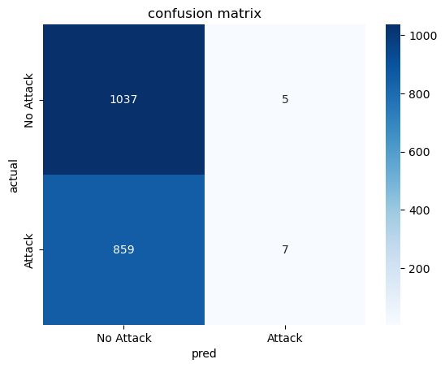

```python
X = cyberData[['session_duration']]  #independent (session duration)
y = cyberData['attack_detected']  # dependent, target variable (attack detection)

X_train, X_test, y_train, y_test = train_test_split(X, y, test_size=0.2, random_state=42)

scaler = StandardScaler()
X_train_scaled = scaler.fit_transform(X_train)
X_test_scaled = scaler.transform(X_test)

lasso = Lasso(alpha=0.01)
lasso.fit(X_train_scaled, y_train)

y_pred = lasso.predict(X_test_scaled)

y_pred_binary = [1 if i >= 0.5 else 0 for i in y_pred]  # assuming 0.5 threshold for attack detection

rmse = mean_squared_error(y_test, y_pred_binary, squared=False)
r2 = r2_score(y_test, y_pred_binary)
conf_matrix = confusion_matrix(y_test, y_pred_binary)

# Output the results
print(f"rmse:{rmse}")
print(f"r^2 Score: {r2}")
print(f"confusion Matrix:\n{conf_matrix}")

sns.heatmap(conf_matrix, annot=True, fmt="d", cmap="Blues", xticklabels=["No Attack", "Attack"], yticklabels=["No Attack", "Attack"])
plt.title("confusion matrix")
plt.xlabel("pred")
plt.ylabel("actual")
plt.show()
```

## interperation:

#### r^2 Score: -0.83 suggests that the model performs worse than random guessing, this means

#### is not capturing the relationship between session duration and attack detection effectively

### confusion matrix:

#### true neg: correctly predicted no attack for 1037 instances

#### false pos: incorrectly predicted attack for 5 instances that were actualy no attack

#### false neg: incorrectly predicted no attack for 859 instances that were actually attack

#### true pos: correctly predicted attack for 7 instances

```python
X = cyberData[['failed_logins', 'session_duration']]# independent variables
y = cyberData['attack_detected']  #dependent variable
#binary: 1 if attack detected, else 0

X_train, X_test, y_train, y_test = train_test_split(X, y, test_size=0.2, random_state=42)

scaler = StandardScaler()
X_train_scaled = scaler.fit_transform(X_train)
X_test_scaled = scaler.transform(X_test)

ridge = Ridge(alpha=1.0)
ridge.fit(X_train_scaled, y_train)

y_pred = ridge.predict(X_test_scaled)

y_pred_binary = [1 if i >= 0.5 else 0 for i in y_pred]

mse = mean_squared_error(y_test, y_pred_binary)
r2 = r2_score(y_test, y_pred_binary)
accuracy = accuracy_score(y_test, y_pred_binary)
conf_matrix = confusion_matrix(y_test, y_pred_binary)

# Output the results
print(f"mse: {mse}")
print(f"r^2 Score: {r2}")
print(f"accuracy: {accuracy}")
print(f"Confusion matrix:\n{conf_matrix}")
```

```
mse: 0.3731656184486373
r^2 Score: -0.505472244262898
accuracy: 0.6268343815513627
Confusion matrix:
[[662 380]
 [332 534]]
```

#### dependent variable: the attack_detected (1 = attack, 0 = no attack) is what i was trying to predict

#### model evaluation: mse: 0.373, not super low, so there’s some prediction error

#### r^2 score: -0.5 so the model is worse than random guessing, it’s not capturing the relationships well

#### accuracy: 62.68%, not great, but better than random

#### interperation: this model isn’t performing well, it’s underfitting: not capturing the patterns in the data, so unrecommended

```
Accuracy: 0.8380503144654088
Precision: 0.0
Confusion Matrix:
[[1599    0]
 [ 309    0]]
```

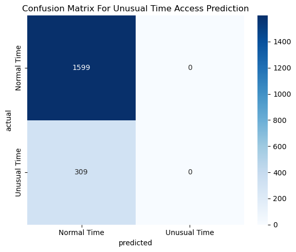

```python
X = cyberData[['failed_logins', 'session_duration', 'network_packet_size']]  #independent variables
y = cyberData['unusual_time_access']  # dpendent variable (unusual access time)

X_train, X_test, y_train, y_test = train_test_split(X, y, test_size=0.2, random_state=42)

scaler = StandardScaler()
X_train_scaled = scaler.fit_transform(X_train)
X_test_scaled = scaler.transform(X_test)

log_reg = LogisticRegression()
log_reg.fit(X_train_scaled, y_train)

y_pred = log_reg.predict(X_test_scaled)

accuracy = accuracy_score(y_test, y_pred)
precision = precision_score(y_test, y_pred)

conf_matrix = confusion_matrix(y_test, y_pred)

print(f"Accuracy: {accuracy}")
print(f"Precision: {precision}")
print(f"Confusion Matrix:\n{conf_matrix}")

plt.figure(figsize=(6, 5))
sns.heatmap(conf_matrix, annot=True, fmt='d', cmap="Blues", xticklabels=["Normal Time", "Unusual Time"], yticklabels=["Normal Time", "Unusual Time"])
plt.title("Confusion Matrix For Unusual Time Access Prediction")
plt.xlabel("predicted")
plt.ylabel("actual")
plt.tight_layout()
plt.show()
```